# Chapter 13: Estimators of $R_0$ derived from mechanistic models

In the book so far we have met a number of mechanistic models. This chapter looks at estimating $R_0$ for these models, with different data available.

There are at least 2 steps to this

- Producing an *estimator* of $R_0$ from the model
- Producing an *estimate* of this estimator from data.

Estimating $R_0$ in an established epidemic is very different to estimating $R_0$ in an emerging epidemic, due to the scarcity of data and lack of knowledge about transmission dynamics etc.

- Generalising estimators presented earlier in the book based on **final-size** epidemic data or **age-structured** endemic data.
- Controlled **transmission experiments** performed to estimate transmission potential and duration of infectivity.
- The infectious agent is emerging for the **first time**

We don't look at situations where a lot is known about an infectious agent, these have been covered earlier, e.g. via analysing the dominant eigenvalue of the next generation matrix.

## Why is estimating $R_0$ hard?

By definition $R_0$ is a **generational** property. It gives, after a sufficient number of generations where the conditions are held constant as if at the start of the epidemic, the per generation growth factor.

Three issues with this definition and reality are:

- Generation data is usually not observed
- What does "sufficiently large" mean?
- Circumstances will not stay fixed for multiple generations (due to the infection infecting a larger proportion of the population, interventions etc.)

Additionally, heterogeneity of the population can cause significant issues with estimating epidemiological parameters from a small sample of data.

To deal with this, we typically need to use simplifying assumptions in low data situations.

# Estimating $R_0$ from final size and age-structure data

Early in the book (chapter 1) we encountered the following estimate for $R_0$ based only only the initial and final proportion of susceptibles.

$$ R_0 = \frac{ - \ln s(\infty )}{ 1 - s(\infty )}$$

This was based on many assumptions

In section 8, for structured populations, estimating the final-size relation required integrating $$ \int_0^\infty A(\tau, x, \eta) d\tau $$ rather than just a scalar $R_0$.

Estimates of $A(\tau, x, \eta)$ are unlikely to be available at the start of an epidemic. Additionally for these models there is no way to express $R_0$ in terms of final size data.

We can estimate $R_0$ is we place some simplifying assumption on age-structured models, such as the force of infection being a constant. In section 4.2 we found the estimator $$R_0 \approx \frac{L}{\bar{a}}$$ where $L$ is the average life expectancy and $\bar{a}$ the expected infection age.

### Estimators of $R_0$ from final size data of small host populations

Estimation in this scenario is inherently stochastic, as the population is too small for the laws of large numbers to hold out.

- Useful when you have a number of small, weakly connected populations (e.g. a infectious agent that spreads easily among families, but rarely between them)
- Also useful when doing controlled experiments on small populations.

In section 5.4 we derived the estimate (ands its variance) $$ R_0^{mrt} = \frac{N}{Y+1} \sum_{k = Y+1}^N \frac{1}{k}$$ Using a martingale method.

- $N$ is the initial number of susceptibles
- $Y$ is the final number of suscepiables

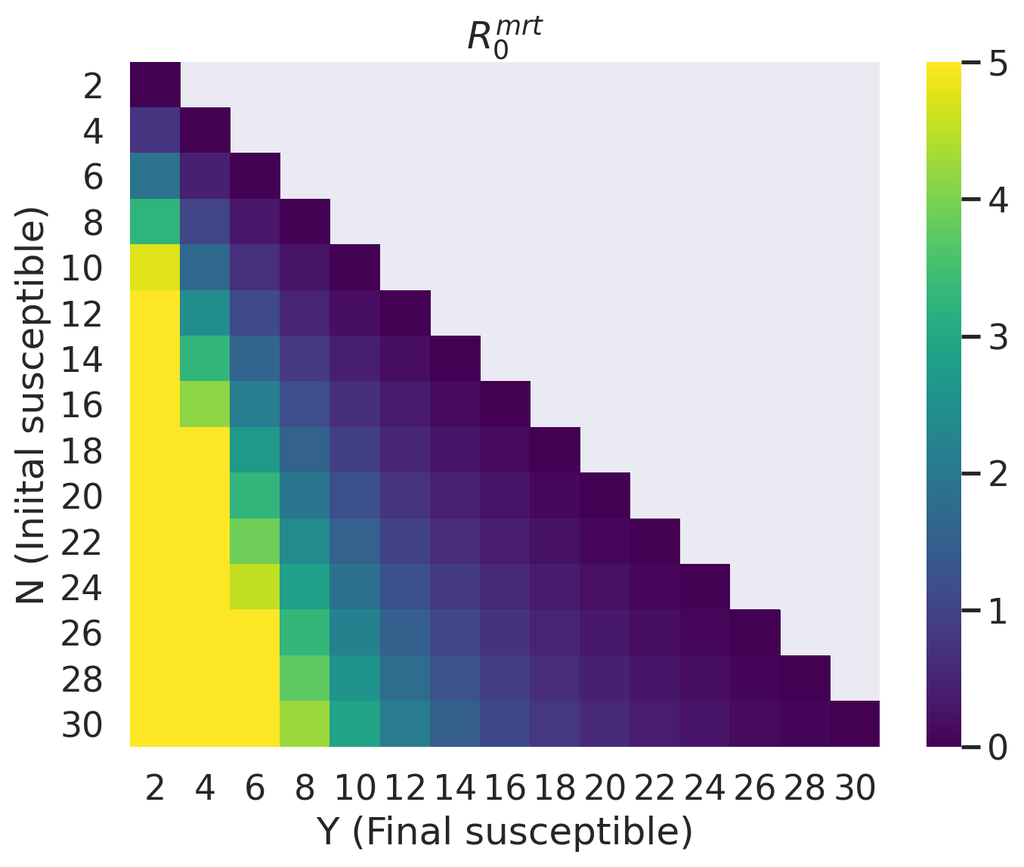

### Estimate $R_0$ from multi-type final-size distribution

Consider the setting in which we know there are $n$ types of individual, in a population of size $N$,

- $\pi_i$ the fraction of the population of type $i$.
- $s_i$ percent of type $i$, are susceptible to the infection at the start of the epidemic.
- $p_i$ percent of type $i$ individual have been infected at the end of the epidemic.

Let $k_{ij} = \int_0^\infty A(\tau, i, j) d \tau $, the expected number of type $j$ infections that a type $i$ infection will cause.

From exercise 8.24, the final size of type $i$ will be (converging in probability in the limit $N \to \infty$) $$ 1 - p_i = \exp \left( - \sum_{j=1}^n \pi_js_jp_jk_{ij} \right) $$

For a single type of population, this would become $$ 1 - p = \exp(-s p R_0)$$ and $$ R_0 = - \frac{\log (1- p)}{sp} $$

In order to determine $R_0$, we would want to compute the largest eigenvalue of the matrix $K$.

Clearly since we have $n$ observations, and $K$ is and $n \times n$ matrix, it will not be possible to estimate $K$ from our observations.

Instead it is possible to derive upper and lower bounds for $R_0$ based on our observations

$$R_0^{min} = \min_i \left[ - \frac{\log(1 - p_i)}{s_i p_i} \right] $$$$R_0^{max} = \max_i \left[ - \frac{\log(1 - p_i)}{s_i p_i} \right]$$

Which we see are just the minimum and maximum $R_0$ from treating each type of population as if it were the only one

## Over to Anna

# Estimating $R_0$ from a transmission experiment

The idea of these experiments is to estimate the transmission rate $\beta$ and the mean length of the infectious period in a controlled setting.

Typically these are not used to estimate $R_0$, but to demonstrate the effectiveness of various treatments, e.g. vaccines. In these cases you might test the null hypothesis $R > 1$ or that the value of $\beta$ with treatment is that same as without.

Typically you lock $N$ individuals in a space for a time $\Delta t$, some of which are infected, some of which are not.

At the end of each trial we have:

- $s$ the number of suceptables (fixed across trials)
- $i$ the number of initially infected (fixed across trials)
- $c$ the number of individuals that become infected during the interval
- The length of the infectious period of each infected individual

Using the *complimentary loglog* transform ($C\log \log[x] = \log(- \log [1-x])$) we get

$$ C\log \log [E(c)/s] = \log \beta + \log[i\Delta t /N]$$

Replacing $E(c)$ with its sample estimate gives us an estimate of $\beta$.

To estimate the infectious period, we take the mean of any fully observed infectious periods of individuals in the trail. This gives and estimate of $T_I = \frac{1}{\alpha}$.

Using both of these we can estimate $R_0 = \frac{N\beta}{\alpha}$.

# Estimating $R_0$ based on the intrinsic growth rate

Estimating $R_0$ in the initial phase of an epidemic can be challenging, in particular if we have never encountered this infectious agent before.

- We will know little about its transmission, latency, incubation, etc.
- At the start we will know nothing about these parameters and distributions
- Early estimates of these will be poor, or unreliable.

We need a "reliable" method to get ball-park estimates $R_0$ in a model-free way, to allow for the planning of interventions, and roughly predicting the initial course of the epidemic without presupposing much about the agent.

Inferring the time-dependent reproduction number $R(t)$ would be very helpful for judging the effect of interventions, but is difficult. This section focuses on inferring $R_0$ only.

## Simple SIR model

Consider the very basic SIR mode, with $$\frac{dI}{dt} = \beta S I /N - \gamma I$$

If we observe simply the doubling time of cases, can we estimate a simple $R_0$?

In the initial phase of the epidemic, assume $S=N$, as the agent is novel: $$\frac{dI}{dt} \approx (\beta - \gamma)I = (R_0 - 1)\gamma I$$

We therefore get exponential growth of the Infected population, with parameter $(R_0 - 1)\gamma$.

If we observe the doubling time $t_d$, then $$2I(t_0) = I(t_0) e^{(R_0 - 1)\gamma t_d}$$

We arrive at $$\hat{R}_0 = 1 + \frac{\ln 2}{\gamma t_d}$$

By observing the doubling time, and observing sick patients to estimate $\gamma$, we can get a crude estimate of $R_0$.

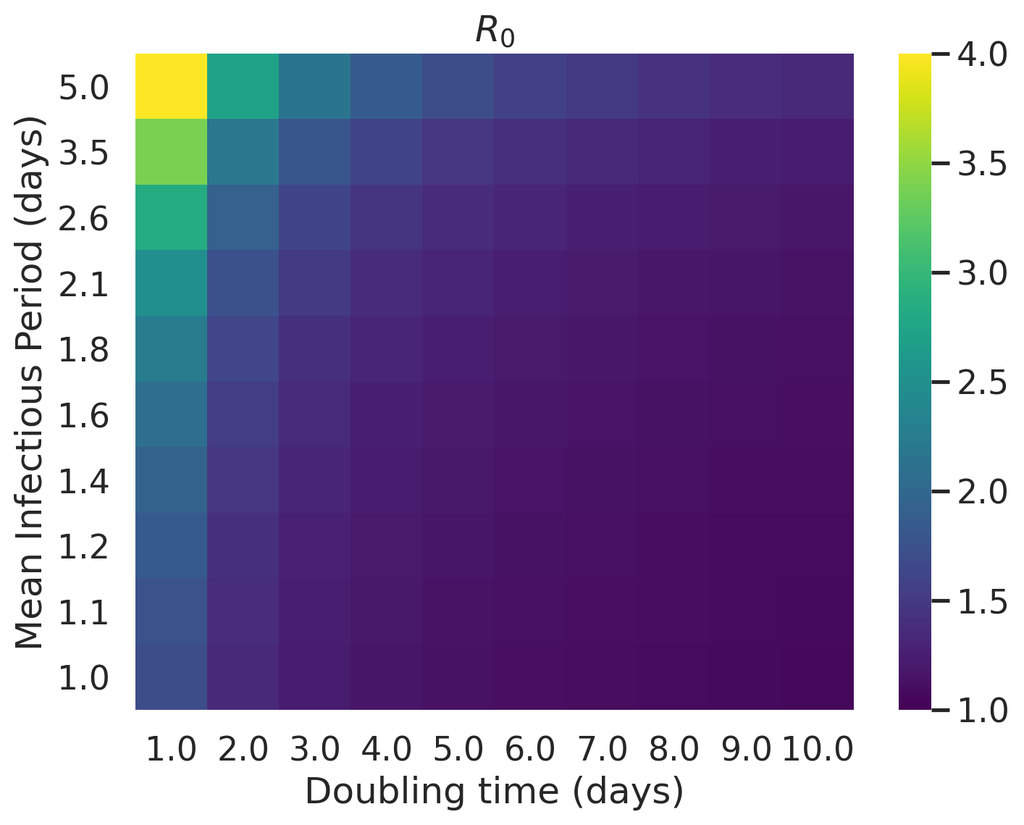

## Moving beyond doubling time

We now look at developing more complex estimators. First, we look at two more reasonably simple estimators to see how they compare to more complex ones we will derive in a moment.

If we estimate from data:

- The exponential growth rate of cumulative infections, $r$
- The generation time, $T_G$

Then we can estimate $R_0$ as $$\hat{R}_0 = e^{rT_G}$$

In the case when $rT_G$ is small, $$\hat{R}_0 = 1 + rT_G$$

We shall label these two estimates as

- $\hat{R}_0^+ = e^{rT_G}$
- $\hat{R}_0^- = 1 + rT_G$

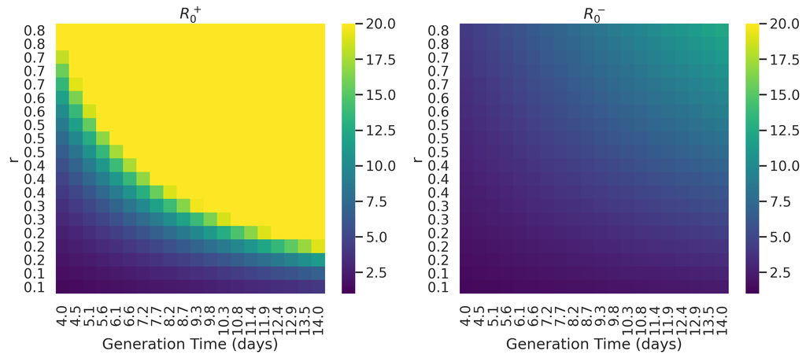

Now for a more complex estimator.

Assume we can write the incidence as $$i(t) = \delta(t) + \frac{S(t)}{N} \int_0^\infty A(\tau) i(t- \tau) d\tau$$ Which just a slight modification from 1.25.

- $\delta(t)$ inserts a new infection at $t=0$
- $A(t)$ absorbs all information about infectious contact between individuals.

The suceptibles in the population at any time are $$S(t) = N - \int_{-\infty}^t i(\tau) d\tau$$

We now write that $$A(t) = R_0 f(t)$$ Where $f(t)$ is some density function, i.e. the likelihood of when in their infection cycle an infected individual will infect another person.

The generation time, $T_G$, is just the expectation of this distribution. $$T_G = \int_0^\infty tf(t) dt$$

In an emerging infection, we may have little information about this distribution $f$. We may however have information about the expected length of the latency period, $T_E$ and the infectious period, $T_I$, with $T_G = T_E + T_I$.

In our model, we will want to impose a form on $f(t)$, given these two quantities. We will investigate next the effect of doing this for different distributions.

As more information about this distribution becomes available, we can refine our choice of $f$.

We will make the following early in the epidemic assumptions:

- $i(t) = e^{rt}$
- $S(t) \approx N$

Using this and our previous equations, we get

$$R_0 \int_0^\infty e^{-rt}f(t) dt = 1$$

This will form that basis of all of the remaining estimates for $R_0$.

## $f(t)$ with an infectious period only

In these estimators we assume that an individual is infectious as soon as they become infected (corresponding to an SIR model).

### $f(t)$ is a delta function

$$f(t) = \delta(t-T_G)$$

In this case we get $$R_0e^{-rT_G} = 1$$ $$R_0 = e^{rT_G}$$

I.e. this is exactly the estimator $R_0^+=e^{rT_G}$

### $f(t)$ is per the standard SIR model (exponential distribution)

$$f(t) = \frac{1}{T_G} e^{-\frac{t}{T_G}}$$

In this case we see that the estimator is just $R_0^- = 1 + rT_G$

## $f(t)$ with latent and infectious periods

In these estimators we assume the individuals are infected, but not infectious, for a period of time after infection (Exposed, corresponding to an SEIR model)

We are going to look at 3 cases for the exposed and infectious time periods:

- Fixed length periods
- Exponentially distributed periods
- Gamma distributed periods

### Fixed lenth periods

In this case $f(t)$ is just a uniform distribution between $T_E$ and $T_E + T_I$

### Exponentially distributed times

- Mean Exposed time is $T_E = \frac{1}{\theta}$
- Mean Infected time is $T_I = \frac{1}{\alpha}$
- mean Generation time is $T_G = T_E + T_I = \frac{1}{\theta} + \frac{1}{\alpha}$

Using a result from an earlier exercise (2.2-i), we arrive at:

$ f(t) = \frac{\alpha \theta}{\alpha - \theta} (e^{- \theta t} - e^{- \theta t}) $

### Gamma distributed times

We can view the Gamma distributed times as a SEIR model where there are $m$ Exposed periods, and $n$ Infected periods (all behaving identically), each with an exponentially distributed amount of time spent in them.

If we vary $m$ and $n$, we keep the mean of these distributions the same, equal to $T_E$ and $T_I$ respectively.

Some special cases of this are:

- For $m,n \to \infty$, we get the fixed length case
- For $m=n=1$, we get the exponential times case

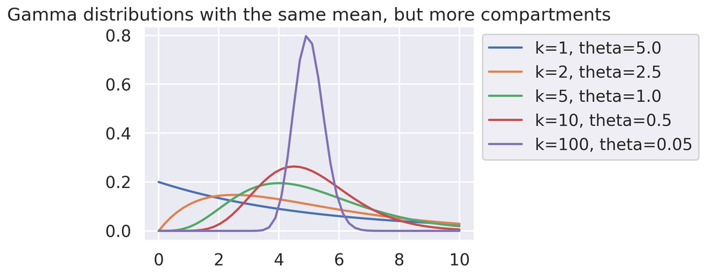

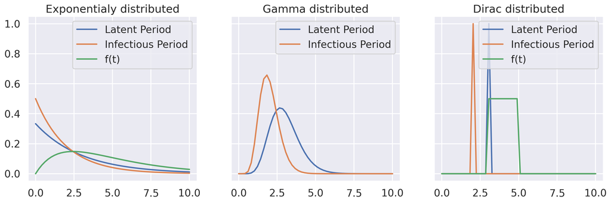

Let us label the estimators as follows:

- Fixed times: $R_0^{fix}$
- Exponential times: $R_0^{exp}$
- Gamma (m,n) times: $R_0^{(m,n)}$

Computing the integrals we find

$$R_0^{fix} = \frac{r T_I}{\sinh rT_I} e^{rT_G}$$$$ R_0^{(m,n)} = \frac{rT_I \left(1 + \frac{rT_E}{m} \right)^m}{1 - \left(1 + \frac{rT_I}{n} \right)^{-n}} $$$$ R_0^{exp} = 1 + rT_G + r^2 T_ET_I$$

With the cases that:

$$ R_0^{(1,1)} = R_0^{exp} $$$$ \lim_{m, n \to \infty} R_0^{(m,n)} = R_0^{fix} $$

And we can arrive at the following ordering

$$ R_0^- \leq R_0^{exp} \leq R_0^{(m,n)} \leq R_0^{fix} \leq R_0^+ $$

And in fact $R_0^+$ is an upper bound for any distribution on $f(t)$

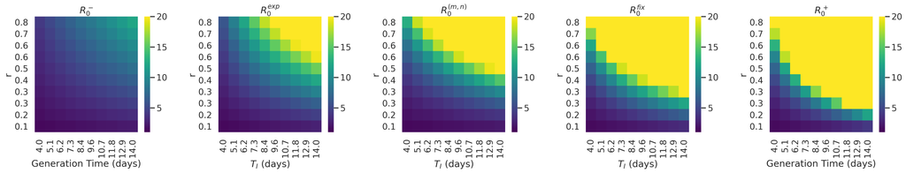